# Aplicación 1.3: Datos financieros

# Propiedades estadísticas básicas de los activos bursátiles

El objetivo de esta aplicación es familiarizarse con la descarga, manejo y visualización de datos bursátiles procedentes de la plataforma [Yahoo!Finanzas](https://es.finance.yahoo.com/), así como entender las propiedades estadísticas básicas de las series temporales asociadas.

Se usará el enfoque *tidyverse* para este tipo de datos, por lo que esta aplicación puede entenderse como un “análisis financiero ordenado” (*tidy finance*). Para una exposición completa de todos los métodos y modelos empíricos recientes de economía financiera puede consultarse la página https://www.tidy-finance.org/ y los libros online (usando R o Python) asociados a la misma.

**Código R**

```r
# Lectura de librerías
library(tidyverse)
library(tidyquant)
library(scales)
#
# Descarga de los datos de un activo bursátil desde Yahoo!Finanzas
#
# Para acceder a los datos diarios del precio de las acciones
# se usa el comando tq_get de la librería tidyquant.
# Solicitaremos los datos del Banco Santander, S.A. (ticker: SAN.MC)
# desde el año 2000:
# https://es.finance.yahoo.com/quote/SAN.MC?p=SAN.MC&.tsrc=fin-srch
#
pSAN <- tq_get("SAN.MC",
  get = "stock.prices",
  from = "2000-01-01",
  to = "2023-12-31"
)
head(pSAN)
```

```
# A tibble: 6 × 8
  symbol date        open  high   low close  volume adjusted
  <chr>  <date>     <dbl> <dbl> <dbl> <dbl>   <dbl>    <dbl>
1 SAN.MC 2000-01-03  9.95  9.99  9.74  9.85 8797337     2.71
2 SAN.MC 2000-01-04  9.73  9.78  9.53  9.62 8811013     2.64
3 SAN.MC 2000-01-05  9.43  9.56  9.30  9.38 9333517     2.58
4 SAN.MC 2000-01-06  9.38  9.38  9.38  9.38       0     2.58
5 SAN.MC 2000-01-07  9.45  9.82  9.44  9.80 9603132     2.69
6 SAN.MC 2000-01-10  9.88  9.88  9.62  9.71 6747710     2.67
```

```r
tail(pSAN)
```

```
# A tibble: 6 × 8
  symbol date        open  high   low close   volume adjusted
  <chr>  <date>     <dbl> <dbl> <dbl> <dbl>    <dbl>    <dbl>
1 SAN.MC 2023-12-20  3.80  3.81  3.74  3.79 27342468     3.63
2 SAN.MC 2023-12-21  3.79  3.81  3.76  3.79 15816650     3.64
3 SAN.MC 2023-12-22  3.79  3.83  3.79  3.81 20983223     3.65
4 SAN.MC 2023-12-27  3.79  3.82  3.76  3.81 33514637     3.65
5 SAN.MC 2023-12-28  3.81  3.82  3.78  3.79 17505114     3.63
6 SAN.MC 2023-12-29  3.79  3.80  3.77  3.78 15848727     3.62
```

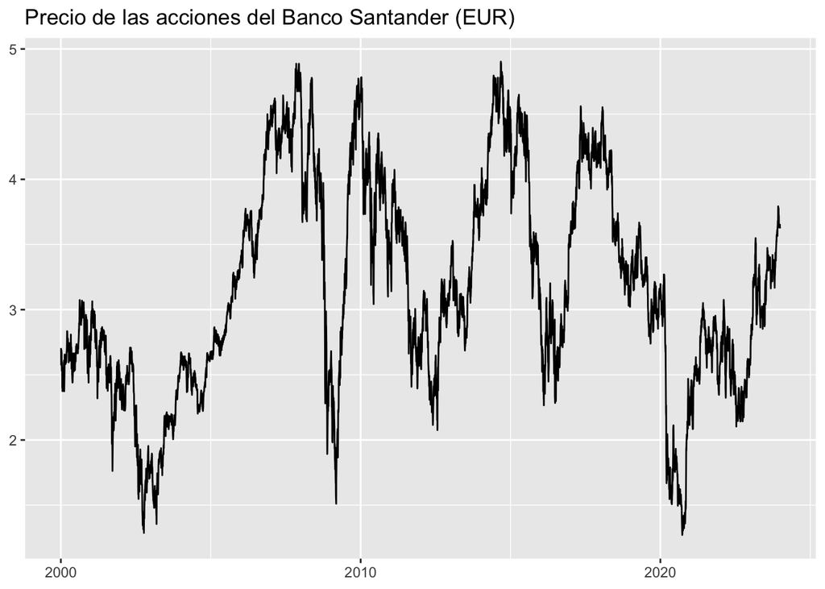

```r
# Gráfica de serie temporal: evolución temporal de los precios
pSAN %>%
  ggplot(aes(x = date, y = adjusted)) +
  geom_line() +
  labs(
    x = NULL,
    y = NULL,
    title = "Precio de las acciones del Banco Santander (EUR)"
  )
```

```r
# Cálculo de los rendimientos netos diarios (returns)
rSAN <- pSAN %>%
  arrange(date) %>%
  mutate(ret = 100*(adjusted / lag(adjusted) - 1)) %>%
  select(symbol, date, ret)
head(rSAN)
```

```
# A tibble: 6 × 3
  symbol date          ret
  <chr>  <date>      <dbl>
1 SAN.MC 2000-01-03 NA
2 SAN.MC 2000-01-04 -2.37
3 SAN.MC 2000-01-05 -2.43
4 SAN.MC 2000-01-06  0
5 SAN.MC 2000-01-07  4.43
6 SAN.MC 2000-01-10 -0.883
```

```r
tail(rSAN)
```

```
# A tibble: 6 × 3
  symbol date           ret
  <chr>  <date>       <dbl>
1 SAN.MC 2023-12-20 -0.0923
2 SAN.MC 2023-12-21  0.106
3 SAN.MC 2023-12-22  0.395
4 SAN.MC 2023-12-27  0.0525
5 SAN.MC 2023-12-28 -0.591
6 SAN.MC 2023-12-29 -0.211
```

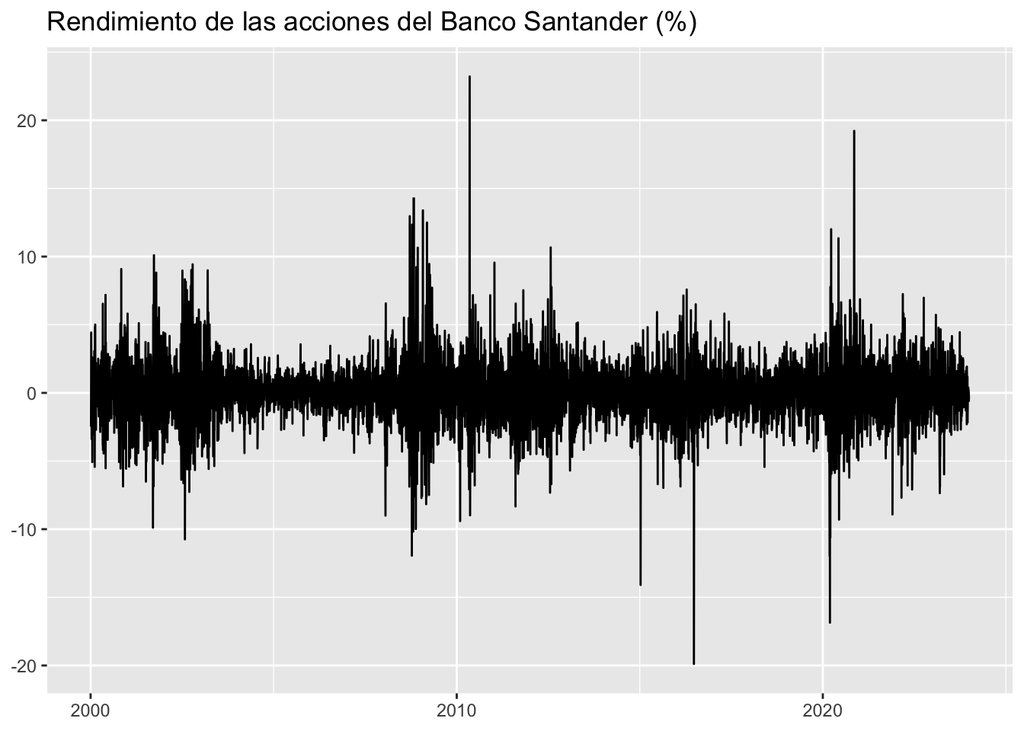

```r
# Eliminación de datos perdidos (missing data)
rSAN <- rSAN %>%
  drop_na(ret)
# Evolución temporal de las rentabilidades diarias
rSAN %>%
  ggplot(aes(x = date, y = ret)) +
  geom_line() +
  labs(
    x = NULL,
    y = NULL,
    title = "Rendimiento de las acciones del Banco Santander (%)"
  )
```

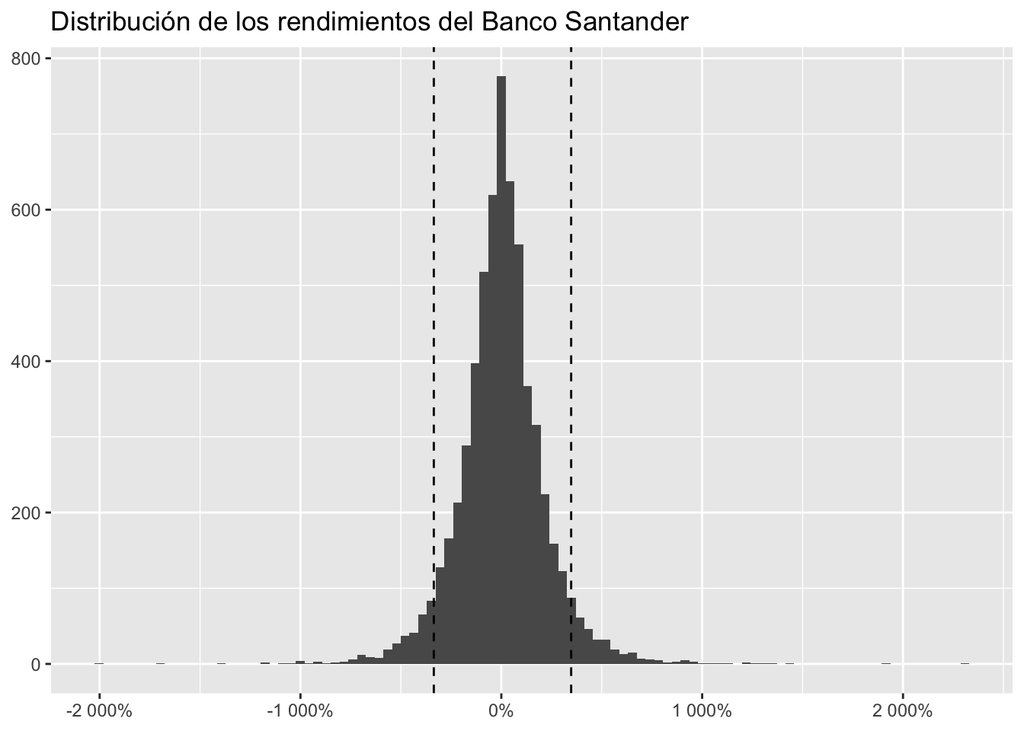

```r
# Distribución de los rendimientos diarios
# (detección de asimetrías y exceso de curtosis)
q5 <- quantile(rSAN %>% pull(ret), probs = 0.05)
q95 <- quantile(rSAN %>% pull(ret), probs = 0.95)
rSAN %>%
  ggplot(aes(x = ret)) +
  geom_histogram(bins = 100) +
  geom_vline(aes(xintercept = q5), linetype = "dashed") +
  geom_vline(aes(xintercept = q95), linetype = "dashed") +
  labs(
    x = NULL,
    y = NULL,
    title = "Distribución de los rendimientos del Banco Santander"
  ) +
  scale_x_continuous(labels = percent)
```

```r
# Estadística resumen global
rSAN %>%
  summarize(across(
    ret,
    list(
      media = mean,
      desv_típica = sd,
      mínimo = min,
      máximo = max
    )
  ))
```

```
# A tibble: 1 × 4
  ret_media ret_desv_típica ret_mínimo ret_máximo
      <dbl>           <dbl>      <dbl>      <dbl>
1    0.0290            2.22      -19.9       23.2
```

```r
# Estadística resumen por años
rSAN %>%
  group_by(year = year(date)) %>%
  summarize(across(
    ret,
    list(
      media = mean,
      desv_típica = sd,
      mínimo = min,
      máximo = max
    ),
    .names = "{.fn}"
  )) %>%
  print(n = Inf)
```

[output not shown]

**Código Python**

```python
# Lectura de librerías
import numpy as np
import pandas as pd
import matplotlib.pyplot as plt
from plotnine import *
from datetime import datetime
from mizani.formatters import percent_format
import yfinance as yf
import warnings
warnings.filterwarnings("ignore")
#
# Descarga de los datos diarios del precio de las acciones del Santander
#
# Creación del ticker del Banco Santander
SAN = yf.Ticker("SAN.MC")
# Lectura de los datos para el período seleccionado
pSAN = yf.download("SAN.MC", start="2000-01-01", end="2023-12-31")
```

```
[*********************100%%**********************]  1 of 1 completed
```

```python
print(pSAN)
```

```
                Open      High       Low     Close  Adj Close    Volume
Date
2000-01-03  9.953261  9.987881  9.736886  9.849401   2.705216   8797337
2000-01-04  9.728231  9.780161  9.529166  9.615716   2.641033   8811013
2000-01-05  9.433961  9.555131  9.304136  9.382031   2.576851   9333517
2000-01-06  9.382031  9.382031  9.382031  9.382031   2.576851         0
2000-01-07  9.451271  9.823436  9.442616  9.797471   2.690955   9603132
...              ...       ...       ...       ...        ...       ...
2023-12-21  3.787500  3.808000  3.759000  3.793000   3.635945  15816650
2023-12-22  3.790500  3.827000  3.785000  3.808000   3.650324  20983223
2023-12-27  3.787000  3.817000  3.759500  3.810000   3.652241  33514637
2023-12-28  3.814000  3.817500  3.775000  3.787500   3.630672  17505114
2023-12-29  3.785500  3.802000  3.772000  3.779500   3.623004  15848727

[6165 rows x 6 columns]
```

```python
pSAN = (pSAN.reset_index())
pSAN.head()
```

```
        Date      Open      High       Low     Close  Adj Close   Volume
0 2000-01-03  9.953261  9.987881  9.736886  9.849401   2.705216  8797337
1 2000-01-04  9.728231  9.780161  9.529166  9.615716   2.641033  8811013
2 2000-01-05  9.433961  9.555131  9.304136  9.382031   2.576851  9333517
3 2000-01-06  9.382031  9.382031  9.382031  9.382031   2.576851        0
4 2000-01-07  9.451271  9.823436  9.442616  9.797471   2.690955  9603132
```

```python
pSAN.tail()
```

```
           Date    Open    High     Low   Close  Adj Close    Volume
6160 2023-12-21  3.7875  3.8080  3.7590  3.7930   3.635945  15816650
6161 2023-12-22  3.7905  3.8270  3.7850  3.8080   3.650324  20983223
6162 2023-12-27  3.7870  3.8170  3.7595  3.8100   3.652241  33514637
6163 2023-12-28  3.8140  3.8175  3.7750  3.7875   3.630672  17505114
6164 2023-12-29  3.7855  3.8020  3.7720  3.7795   3.623004  15848727
```

```
<Figure Size: (640 x 480)>
```

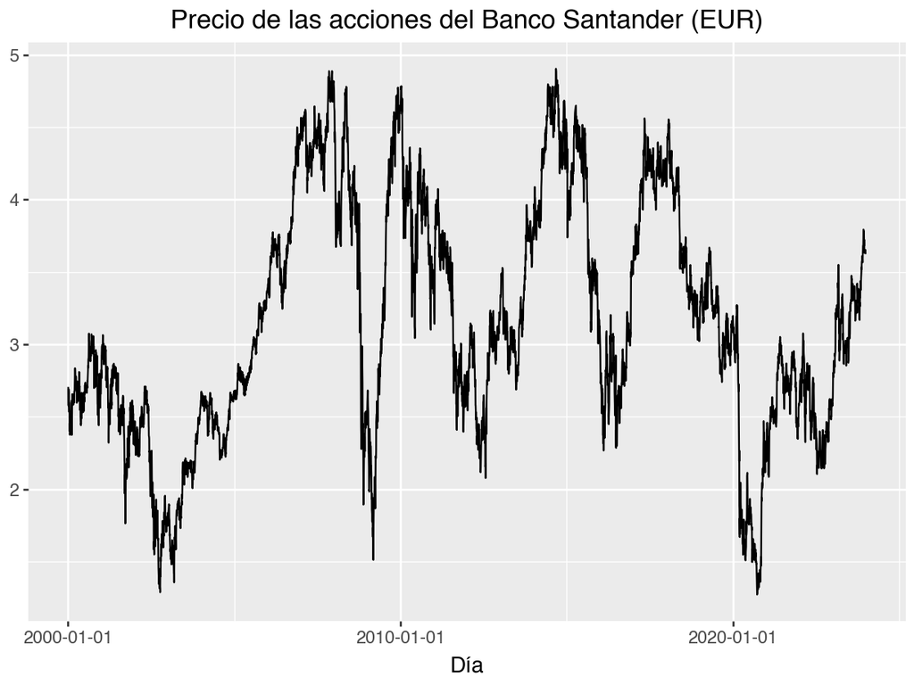

```python
# Gráfica de serie temporal: evolución temporal de los precios
(
  ggplot(pSAN, aes(y="Adj Close", x="Date"))
  + geom_line()
  + labs(x="Día", y="", title="Precio de las acciones del Banco Santander (EUR)")
)
```

```python
# Cálculo de los rendimientos netos diarios
def ret(x):
    x_change = 100*(x/x.shift(1)-1)
    return x_change
pSAN['ret'] = ret(pSAN['Adj Close'])
pSAN['ret']
```

```
0            NaN
1      -2.372573
2      -2.430178
3       0.000000
4       4.428051
          ...
6160    0.105572
6161    0.395469
6162    0.052513
6163   -0.590556
6164   -0.211214
Name: ret, Length: 6165, dtype: float64
```

```
<Figure Size: (640 x 480)>
```

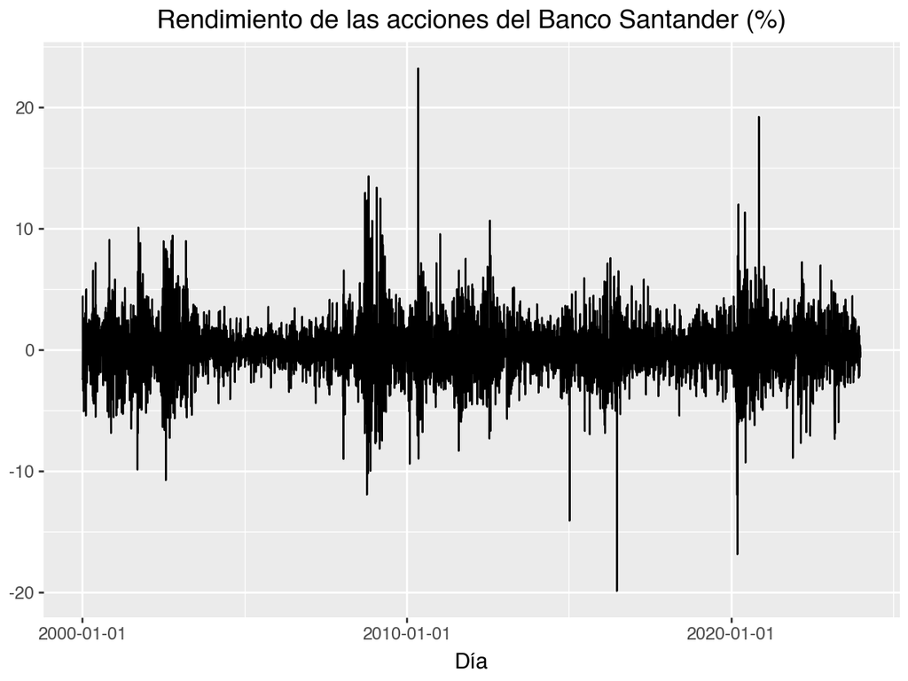

```python
# Eliminación de datos perdidos (missing data)
pSAN = pSAN.dropna()
# Evolución temporal de las rentabilidades diarias
(
  ggplot(pSAN, aes(y="ret", x="Date"))
 + geom_line()
 + labs(x="Día", y="",
 title="Rendimiento de las acciones del Banco Santander (%)")
)
```

```
<Figure Size: (640 x 480)>
```

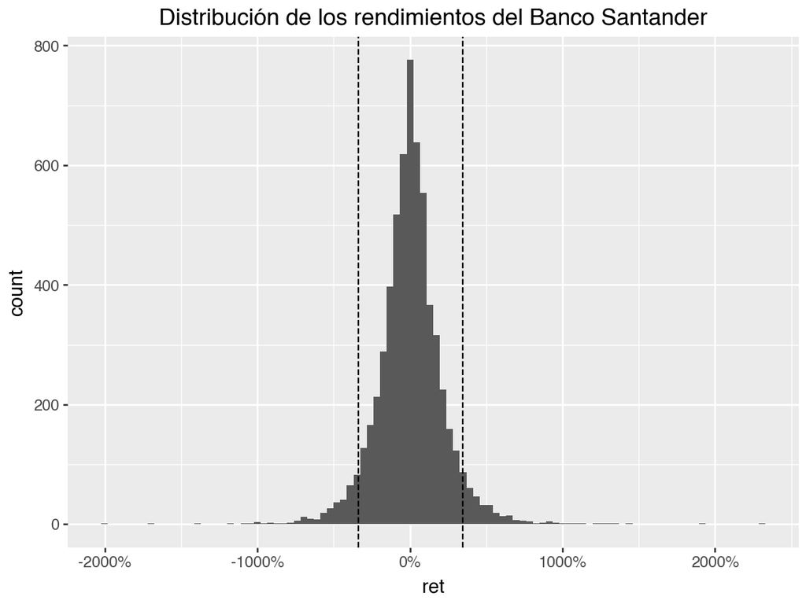

```python
# Distribución de los rendimientos diarios
# (detección de asimetrías y exceso de curtosis)
q5 = pSAN["ret"].quantile(0.05)
q95 = pSAN["ret"].quantile(0.95)
(
  ggplot(pSAN, aes(x="ret"))
 + geom_histogram(bins=100)
 + geom_vline(aes(xintercept=q5), linetype="dashed")
 + geom_vline(aes(xintercept=q95), linetype="dashed")
 + labs(x=None, y=None,
 title="Distribución de los rendimientos del Banco Santander")
 + scale_x_continuous(labels=percent_format())
)
```

```python
# Estadística resumen global
est_res = pSAN['ret'].agg({
    'media': 'mean',
    'desv_típica': 'std',
    'mínimo': 'min',
    'máximo': 'max'
})
est_res.round(3)
```

```
media           0.029
desv_típica     2.221
mínimo        -19.886
máximo         23.217
Name: ret, dtype: float64
```

```python
# Estadística resumen por años
pSAN['year'] = pSAN["Date"].dt.year
est_anual = pSAN.groupby('year').agg({'ret': ['mean', 'std', 'min', 'max']})
est_anual.round(3)
```

```
        ret
       mean    std     min     max
year
2000  0.042  2.295  -6.863   9.085
2001 -0.028  2.525  -9.884  10.101
2002 -0.076  3.127 -10.743   9.434
2003  0.176  2.085  -5.581   8.989
2004  0.013  1.155  -4.417   3.571
2005  0.095  0.885  -3.128   3.565
2006  0.113  1.097  -3.480   3.455
2007  0.042  1.318  -4.396   4.151
2008 -0.200  3.410 -11.942  14.328
2009  0.283  2.907  -8.163  13.391
2010 -0.083  2.859  -9.403  23.217
2011 -0.052  2.393  -8.332   9.560
2012  0.091  2.409  -7.321  10.675
2013  0.079  1.640  -5.700   5.165
2014  0.070  1.412  -4.029   3.777
2015 -0.121  2.064 -14.090   5.932
2016  0.092  2.779 -19.886   7.582
2017  0.070  1.402  -3.828   5.820
2018 -0.100  1.376  -5.432   3.729
2019  0.009  1.541  -4.286   4.290
2020 -0.068  3.633 -16.858  19.222
2021  0.085  1.923  -8.918   6.872
2022  0.022  2.214  -7.691   7.249
2023  0.150  1.793  -7.355   5.726
```

# Comportamiento temporal de los activos bursátiles

En esta aplicación se analizará gráficamente la relación existente entre las variables financieras $rSAN_t$ y $rIBEX_t$, donde $rSAN$ es el rendimiento (no el precio) de las acciones del Banco Santander y $rIBEX$ es el rendimiento del índice bursátil Ibex 35 (https://en.wikipedia.org/wiki/IBEX_35).

Durante la aplicación, se tendrán que ejecutar comandos específicos de filtrado, selección, transformación, fusión de ficheros, agrupación, ordenación y resumen, todas ellos asociados a operaciones básicas en la gestión de datos.

**Código R**

```r
# Comportamiento Banco Santander/Ibex 35
# Lectura de librerías
library(tidyverse)
library(lubridate)
library(scales)
# Lectura de datos de las 30 mayores empresas del Ibex 35
datos_acciones <- read_csv("data/IBEX_top30.csv")
head(datos_acciones)
```

```
# A tibble: 6 × 10
   ...1 symbol date        open  high   low close volume adjusted company_name
  <dbl> <chr>  <date>     <dbl> <dbl> <dbl> <dbl>  <dbl>    <dbl> <chr>
1     1 RED.MC 2000-01-03  1.52  1.54  1.48  1.49 775472    0.510 Redeia Corpor…
2     2 RED.MC 2000-01-04  1.50  1.50  1.41  1.41 786100    0.484 Redeia Corpor…
3     3 RED.MC 2000-01-05  1.41  1.49  1.40  1.43 702520    0.490 Redeia Corpor…
4     4 RED.MC 2000-01-07  1.48  1.51  1.44  1.5  319884    0.514 Redeia Corpor…
5     5 RED.MC 2000-01-10  1.51  1.52  1.50  1.5  256932    0.514 Redeia Corpor…
6     6 RED.MC 2000-01-11  1.5   1.52  1.5   1.5  290704    0.514 Redeia Corpor…
```

```r
tail(datos_acciones)
```

```
# A tibble: 6 × 10
    ...1 symbol date        open  high   low close  volume adjusted company_name
   <dbl> <chr>  <date>     <dbl> <dbl> <dbl> <dbl>   <dbl>    <dbl> <chr>
1 143543 GRF.MC 2023-12-20  14.5  14.7  14.4  14.5 1160818     14.5 Grifols, S.…
2 143544 GRF.MC 2023-12-21  14.3  14.4  14.2  14.3  648586     14.3 Grifols, S.…
3 143545 GRF.MC 2023-12-22  14.2  14.4  14.1  14.3  614762     14.3 Grifols, S.…
4 143546 GRF.MC 2023-12-27  14.3  14.5  14.1  14.2  877076     14.2 Grifols, S.…
5 143547 GRF.MC 2023-12-28  14.2  14.2  14.1  14.2  665813     14.2 Grifols, S.…
6 143548 GRF.MC 2023-12-29  14.2  15.9  14.2  15.5 4301699     15.5 Grifols, S.…
```

```r
# filter
SAN <- datos_acciones %>% filter(symbol == "SAN.MC")
# select
pSAN <- SAN %>% select(date, adjusted)
head(pSAN)
```

```
# A tibble: 6 × 2
  date       adjusted
  <date>        <dbl>
1 2000-01-03     2.60
2 2000-01-04     2.54
3 2000-01-05     2.48
4 2000-01-06     2.48
5 2000-01-07     2.59
6 2000-01-10     2.57
```

```r
tail(pSAN)
```

```
# A tibble: 6 × 2
  date       adjusted
  <date>        <dbl>
1 2023-12-20     3.79
2 2023-12-21     3.79
3 2023-12-22     3.81
4 2023-12-27     3.81
5 2023-12-28     3.79
6 2023-12-29     3.78
```

```r
# Lectura de datos del índice Ibex 35
IBEX <- read_csv("data/IBEX.csv")
# select
pIBEX <- IBEX %>% select(date,adjusted)
head(pIBEX)
```

```
# A tibble: 6 × 2
  date       adjusted
  <date>        <dbl>
1 2000-01-03   11610.
2 2000-01-04   11207.
3 2000-01-05   10863.
4 2000-01-07   11102.
5 2000-01-10   11173.
6 2000-01-11   11012.
```

```r
tail(pIBEX)
```

```
# A tibble: 6 × 2
  date       adjusted
  <date>        <dbl>
1 2023-12-20   10101
2 2023-12-21   10104.
3 2023-12-22   10112.
4 2023-12-27   10122.
5 2023-12-28   10086.
6 2023-12-29   10102.
```

```r
# join
IBEX_SAN <- inner_join(pIBEX, pSAN, by = "date") %>%
  rename(pIBEX = adjusted.x, pSAN = adjusted.y)
# mutate
IBEX_SAN <- IBEX_SAN %>%
  mutate(year = year(date), month = month(date))
IBEX_SAN  <- IBEX_SAN %>%
  mutate(rSAN = 100*(pSAN / lag(pSAN) - 1),
         rIBEX = 100*(pIBEX / lag(pIBEX) - 1))
head(IBEX_SAN)
```

```
# A tibble: 6 × 7
  date        pIBEX  pSAN  year month   rSAN  rIBEX
  <date>      <dbl> <dbl> <dbl> <dbl>  <dbl>  <dbl>
1 2000-01-03 11610.  2.60  2000     1 NA     NA
2 2000-01-04 11207.  2.54  2000     1 -2.37  -3.47
3 2000-01-05 10863.  2.48  2000     1 -2.43  -3.07
4 2000-01-07 11102.  2.59  2000     1  4.43   2.20
5 2000-01-10 11173.  2.57  2000     1 -0.883  0.639
6 2000-01-11 11012.  2.48  2000     1 -3.39  -1.44
```

```r
tail(IBEX_SAN)
```

```
# A tibble: 6 × 7
  date        pIBEX  pSAN  year month    rSAN   rIBEX
  <date>      <dbl> <dbl> <dbl> <dbl>   <dbl>   <dbl>
1 2023-12-20 10101   3.79  2023    12 -0.0923 -0.0564
2 2023-12-21 10104.  3.79  2023    12  0.106   0.0327
3 2023-12-22 10112.  3.81  2023    12  0.395   0.0752
4 2023-12-27 10122.  3.81  2023    12  0.0525  0.0979
5 2023-12-28 10086.  3.79  2023    12 -0.591  -0.352
6 2023-12-29 10102.  3.78  2023    12 -0.211   0.158
```

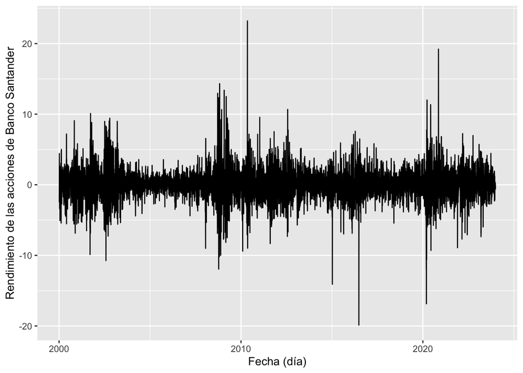

```r
# Eliminación de datos perdidos (missing data)
IBEX_SAN <- IBEX_SAN |> drop_na()
# ggplot
p1 <- ggplot(data = IBEX_SAN, aes(x = date)) +
  geom_line(aes(y = rSAN), linewidth = 0.5) +
  labs(y = "Rendimiento de las acciones de Banco Santander",
       x = "Fecha (día)")
p1
```

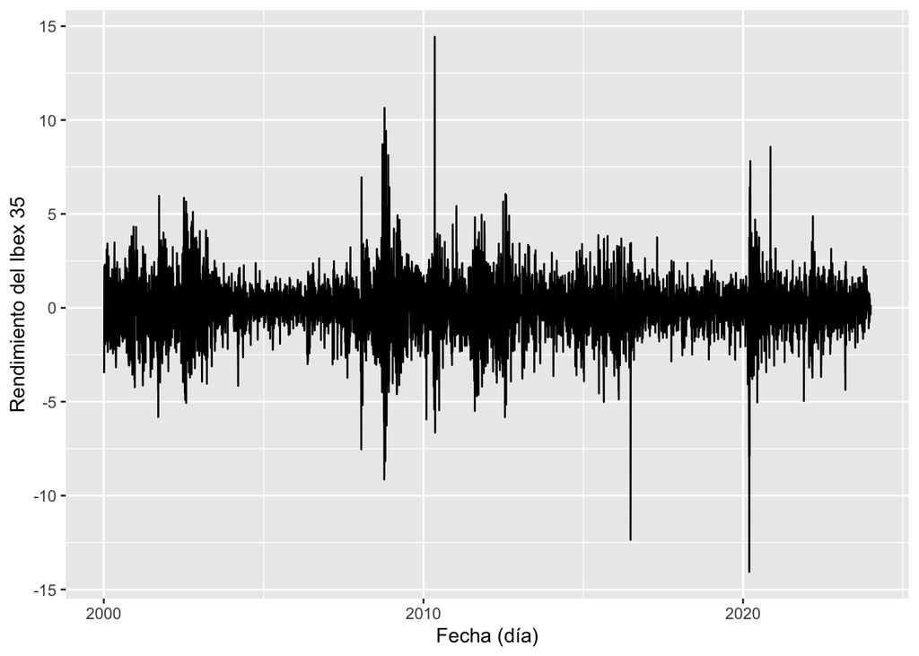

```r
p2 <- ggplot(data = IBEX_SAN, aes(x = date)) +
  geom_line(aes(y = rIBEX), linewidth = 0.5) +
  labs(y = "Rendimiento del Ibex 35",
       x = "Fecha (día)")
p2
```

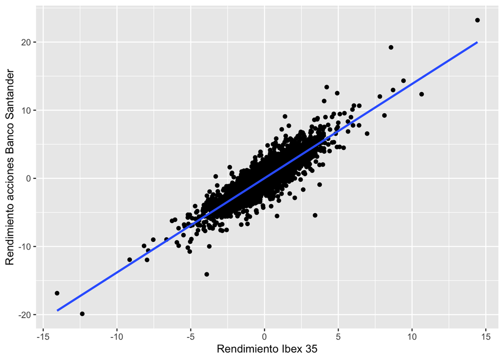

```r
p3 <- ggplot(IBEX_SAN, aes(x = rIBEX, y = rSAN)) +
               geom_point() +
               stat_smooth(method = lm, se = FALSE) +
               labs(x = "Rendimiento Ibex 35",
                    y = "Rendimiento acciones Banco Santander")
p3
```

**Código Python**

```python
# Comportamiento Banco Santander/Ibex 35
# Lectura de librerías
import numpy as np
import pandas as pd
import matplotlib.pyplot as plt
from plotnine import *
from datetime import datetime
# Lectura de datos 30 mayores empresas del Ibex 35
datos_acciones = pd.read_csv('data/IBEX_top30.csv')
datos_acciones.head()
```

```
   Unnamed: 0  symbol        date  ...  volume  adjusted              company_name
0           1  RED.MC  2000-01-03  ...  775472  0.510131  Redeia Corporación, S.A.
1           2  RED.MC  2000-01-04  ...  786100  0.483597  Redeia Corporación, S.A.
2           3  RED.MC  2000-01-05  ...  702520  0.490445  Redeia Corporación, S.A.
3           4  RED.MC  2000-01-07  ...  319884  0.513555  Redeia Corporación, S.A.
4           5  RED.MC  2000-01-10  ...  256932  0.513555  Redeia Corporación, S.A.

[5 rows x 10 columns]
```

```python
datos_acciones.tail()
```

```
        Unnamed: 0  symbol        date  ...   volume  adjusted   company_name
143543      143544  GRF.MC  2023-12-21  ...   648586    14.345  Grifols, S.A.
143544      143545  GRF.MC  2023-12-22  ...   614762    14.280  Grifols, S.A.
143545      143546  GRF.MC  2023-12-27  ...   877076    14.180  Grifols, S.A.
143546      143547  GRF.MC  2023-12-28  ...   665813    14.230  Grifols, S.A.
143547      143548  GRF.MC  2023-12-29  ...  4301699    15.455  Grifols, S.A.

[5 rows x 10 columns]
```

```python
# filter
SAN = datos_acciones[datos_acciones['symbol']=='SAN.MC']
# select
pSAN = SAN[['date','adjusted']]
pSAN['date'] = pd.to_datetime(pSAN['date'])
pSAN.head()
```

```
            date  adjusted
49011 2000-01-03  2.603297
49012 2000-01-04  2.541533
49013 2000-01-05  2.479767
49014 2000-01-06  2.479767
49015 2000-01-07  2.589572
```

```python
pSAN.tail()
```

```
            date  adjusted
55171 2023-12-21    3.7930
55172 2023-12-22    3.8080
55173 2023-12-27    3.8100
55174 2023-12-28    3.7875
55175 2023-12-29    3.7795
```

```python
# Lectura de datos del índice Ibex 35
IBEX = pd.read_csv('data/IBEX.csv')
# select
pIBEX = IBEX[['date','adjusted']]
# mutate
pIBEX['date'] = pd.to_datetime(pIBEX['date'])
pIBEX.head()
```

```
        date      adjusted
0 2000-01-03  11609.988281
1 2000-01-04  11206.587891
2 2000-01-05  10863.088867
3 2000-01-07  11102.388672
4 2000-01-10  11173.288086
```

```python
pIBEX.tail()
```

```
           date      adjusted
6097 2023-12-21  10104.299805
6098 2023-12-22  10111.900391
6099 2023-12-27  10121.799805
6100 2023-12-28  10086.200195
6101 2023-12-29  10102.099609
```

```python
# merge (join)
IBEX_SAN = pd.merge(pIBEX, pSAN, how='inner', on='date').\
    rename(columns={'adjusted_x':'pIBEX','adjusted_y':'pSAN'})
# time
IBEX_SAN['year'] = IBEX_SAN['date'].dt.year
IBEX_SAN['month'] = IBEX_SAN['date'].dt.month
# Cálculo de los rendimientos netos diarios
IBEX_SAN['rSAN'] = 100*(IBEX_SAN['pSAN']/IBEX_SAN['pSAN'].shift(1)-1)
IBEX_SAN['rIBEX'] = 100*(IBEX_SAN['pIBEX']/IBEX_SAN['pIBEX'].shift(1)-1)
IBEX_SAN.head()
```

```
        date         pIBEX      pSAN  year  month      rSAN     rIBEX
0 2000-01-03  11609.988281  2.603297  2000      1       NaN       NaN
1 2000-01-04  11206.587891  2.541533  2000      1 -2.372548 -3.474598
2 2000-01-05  10863.088867  2.479767  2000      1 -2.430243 -3.065153
3 2000-01-07  11102.388672  2.589572  2000      1  4.428031  2.202871
4 2000-01-10  11173.288086  2.566696  2000      1 -0.883399  0.638596
```

```python
IBEX_SAN.tail()
```

```
           date         pIBEX    pSAN  year  month      rSAN     rIBEX
6096 2023-12-21  10104.299805  3.7930  2023     12  0.105567  0.032668
6097 2023-12-22  10111.900391  3.8080  2023     12  0.395468  0.075221
6098 2023-12-27  10121.799805  3.8100  2023     12  0.052517  0.097899
6099 2023-12-28  10086.200195  3.7875  2023     12 -0.590552 -0.351712
6100 2023-12-29  10102.099609  3.7795  2023     12 -0.211218  0.157635
```

```
<Figure Size: (640 x 480)>
```

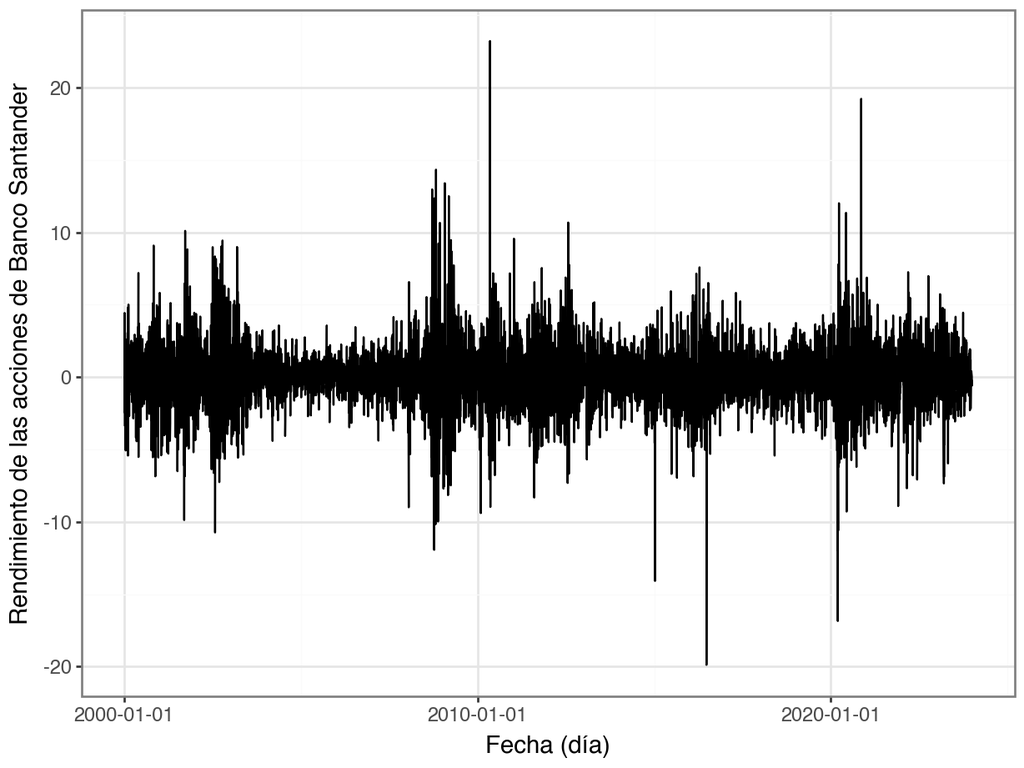

```python
# Eliminación de datos perdidos (missing data)
IBEX_SAN = IBEX_SAN.dropna()
# ggplot (plotnine)
(ggplot(IBEX_SAN) + geom_line(aes('date','rSAN'), size = 0.5) +
labs(y = "Rendimiento de las acciones de Banco Santander", x = "Fecha (día)") +
theme_bw())
```

```
<Figure Size: (640 x 480)>
```

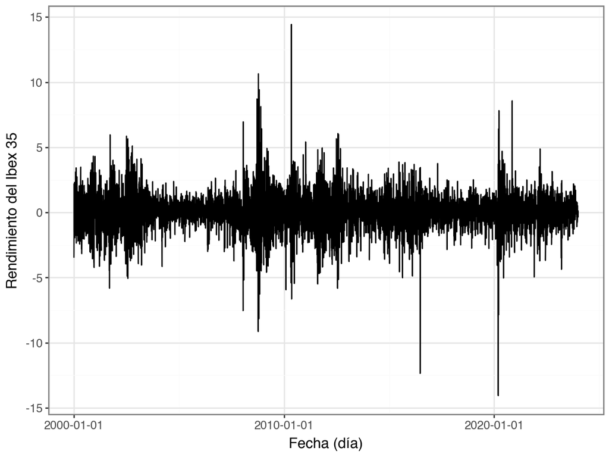

```python
(ggplot(IBEX_SAN) + geom_line(aes('date','rIBEX'), size = 0.5) +
labs(y = "Rendimiento del Ibex 35", x = "Fecha (día)") +
theme_bw())
```

```
<Figure Size: (640 x 480)>
```

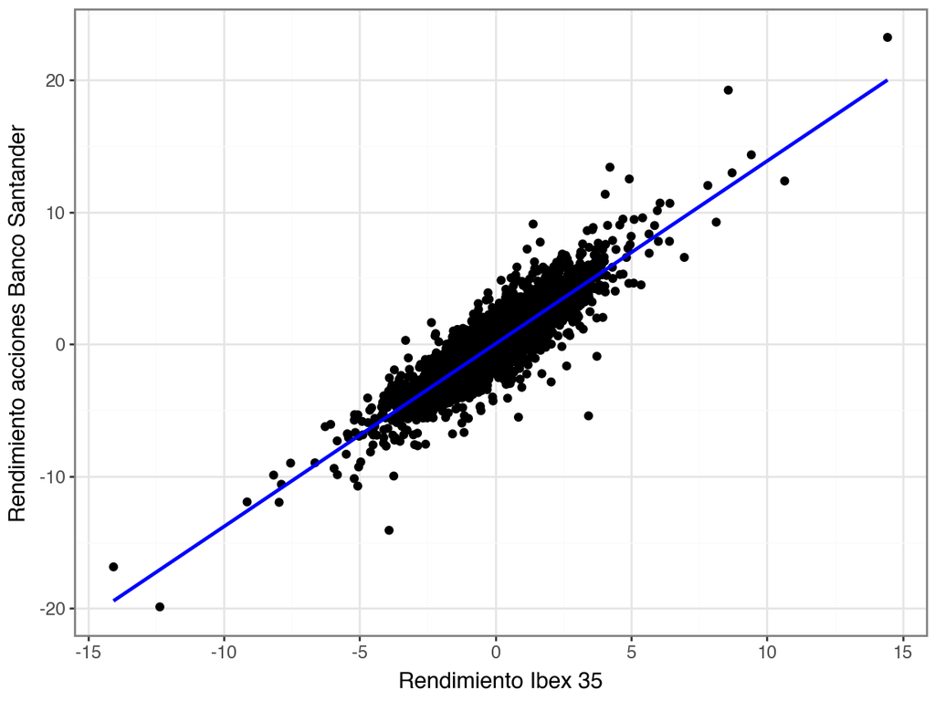

```python
(ggplot(IBEX_SAN, aes('rIBEX','rSAN')) + geom_point() +
geom_smooth(method = 'lm', se = False, color = "blue") +
labs(x="Rendimiento Ibex 35", y="Rendimiento acciones Banco Santander") +
theme_bw())
```